# Time Series HW8

B082040005 高念慈

2023-04-14

## 1.

$$(a) Z_t=a_t$$

- 1. Simulate 100 observations from the following process:  
     Where $a_{t} ~ WN(0,1)$  
     Compute the sample ACF of {$Z_t$},i.e,$\hat\rho_k$ for k=1,2,3

### 模擬

```r
set.seed(20230414)
WN_sim <- arima.sim(list(order=c(0,0,0), sq=sqrt(1)), n=100)
acf(WN_sim, type="correlation", plot=FALSE, lag.max=3)
```

```
##
## Autocorrelations of series 'WN_sim', by lag
##
##      0      1      2      3
##  1.000 -0.033 -0.042  0.014
```

- 2. Repeating (i) for 1000 times to find the values of  
     the mean, variance and covariance of$\hat\rho_1,\hat\rho_2$ and $\hat\rho_3$

### mean, variance and covariance

```r
set.seed(20230414)

M = 1000

rho_1 = rep(0,M);rho_2 = rep(0,M);rho_3 = rep(0,M)

for (i in 1:M){
  WN_sim = arima.sim(list(order=c(0,0,0), sq=sqrt(1)), n=100)
  ar100_acf = acf(WN_sim, type="correlation", plot=FALSE, lag.max=3)[[1]]  # ACF
  rho_1[i] = ar100_acf[2]
  rho_2[i] = ar100_acf[3]
  rho_3[i] = ar100_acf[4]
}

cbind(mean_rho = c(mean(rho_1),mean(rho_2),mean(rho_3)),
      var_rho = c(var(rho_1),var(rho_2),var(rho_3)))
```

```
##          mean_rho     var_rho
## [1,] -0.013203291 0.009791758
## [2,] -0.008934660 0.009809279
## [3,] -0.009377751 0.010092048
```

### covariance

```r
rbind(co_rho12 = cov(rho_1,rho_2),
      co_rho23 = cov(rho_2,rho_3),
      co_rho13 = cov(rho_1,rho_3))
```

```
##                   [,1]
## co_rho12 -8.861869e-05
## co_rho23 -9.272359e-06
## co_rho13 -8.363077e-04
```

- 3. Compare the result of (ii) with the Bartlett’s formula.(p35,36)

$$\because White \; noise \; Var(\hatρ_k)
≈ \frac{1}{n}$$
$$\therefore
Var(\hatρ_1) = Var(\hatρ_2) = Var(\hatρ_3) ≈ 0.01$$
$$White \; noise \; process,each\;ρi, ρj \; for \;i
≠ j \;are\; approximately \;uncorrelated$$
$$∴ Cov(\hatρ_1, \hatρ_2) = Cov(\hatρ_1, \hatρ_3) =
Cov(\hatρ_2, \hatρ_3) ≈ 0$$

- 結果都跟(ii)差不多

$$(b) Z_t=a_t-1.5a_{t-1}$$

- 1. Simulate 100 observations from the following process:  
     Where $a_{t} ~ WN(0,1)$  
     Compute the sample ACF of {$Z_t$},i.e,$\hat\rho_k$ for k=1,2,3

### 模擬

```r
set.seed(20230414)
WN_sim2 = arima.sim(model = list(order=c(0,0,1), ma=c(-1.5)),
                    sd = sqrt(1),
                    n = 100)
acf(WN_sim2, type="correlation", plot=FALSE, lag.max=3)
```

```
##
## Autocorrelations of series 'WN_sim2', by lag
##
##      0      1      2      3
##  1.000 -0.454 -0.029  0.019
```

- 2. Repeating (i) for 1000 times to find the values of  
     the mean, variance and covariance of$\hat\rho_1,\hat\rho_2$ and $\hat\rho_3$

### mean, variance and covariance

```r
set.seed(20230414)

M = 1000

rho_1 = rep(0,M);rho_2 = rep(0,M);rho_3 = rep(0,M)

for (i in 1:M){
  WN_sim2 = arima.sim(model = list(order=c(0,0,1), ma=c(-1.5)),
                      sd = sqrt(1), n = 100)
  ar100_acf = acf(WN_sim2, type="correlation", plot=FALSE, lag.max=3)[[1]]  # ACF
  rho_1[i] = ar100_acf[2]
  rho_2[i] = ar100_acf[3]
  rho_3[i] = ar100_acf[4]
}

cbind(mean_rho = c(mean(rho_1),mean(rho_2),mean(rho_3)),
      var_rho = c(var(rho_1),var(rho_2),var(rho_3)))
```

```
##           mean_rho     var_rho
## [1,] -0.4541391934 0.005449826
## [2,] -0.0040762526 0.013105427
## [3,]  0.0004236458 0.013248544
```

### covariance

```r
rbind(co_rho12 = cov(rho_1,rho_2),
      co_rho23 = cov(rho_2,rho_3),
      co_rho13 = cov(rho_1,rho_3))
```

```
##                  [,1]
## co_rho12 -0.006766043
## co_rho23 -0.008239759
## co_rho13  0.001503095
```

- 3. Compare the result of (ii) with the Bartlett’s formula.
- 紙上

## 3.

Consider the monthly U.S. unemployment rate from January 1948 to  
March 2009 in the file m-unrate.txt. The data are seasonally adjusted  
and obtained from the Federal Reserve Bank of St Louis. Build an AR  
time series model for the series and use the model to forecast the  
unemployment rate for the April, May, June, and July of 2009. In  
addition, does the fitted model imply the existence of business cycles?  
Why? (Note that there are more than one model fits the data well. You  
only need an adequate model.)

### the monthly U.S. unemployment rate

```r
unrate = read.table('https://faculty.chicagobooth.edu/-/media/faculty/ruey-s-tsay/teaching/fts3/m-unrate.txt',header = T)
head(unrate)
```

```
##   Year Mon Day Rate
## 1 1948   1   1  3.4
## 2 1948   2   1  3.8
## 3 1948   3   1  4.0
## 4 1948   4   1  3.9
## 5 1948   5   1  3.5
## 6 1948   6   1  3.6
```

### Build an AR time series model (You only need an adequate model.)

1. **找P**

```r
m1 = ar(unrate$Rate, aic=TRUE, method='mle')
m1$order
```

```
## [1] 11
```

```r
m11 = arima(unrate$Rate, order=c(11,0,0))
m11
```

```
##
## Call:
## arima(x = unrate$Rate, order = c(11, 0, 0))
##
## Coefficients:
##          ar1     ar2      ar3      ar4     ar5      ar6      ar7     ar8
##       0.9886  0.2375  -0.0741  -0.0630  0.0301  -0.1283  -0.0426  0.0539
## s.e.  0.0367  0.0516   0.0525   0.0525  0.0526   0.0524   0.0526  0.0527
##           ar9     ar10    ar11  intercept
##       -0.0146  -0.1293  0.1259     5.6554
## s.e.   0.0526   0.0518  0.0371     0.4422
##
## sigma^2 estimated as 0.03867:  log likelihood = 150.03,  aic = -274.07
```

2. **刪不重要的係數**
- ar3 : -0.17896726,0.03084811
- ar4 : -0.16791970,0.04196004
- ar5 : -0.07516071,0.13542866
- ar7 : -0.14788610,0.06262882
- ar8 : -0.05139841,0.15921055
- ar9 : -0.11978259,0.09062277

```r
Box.test(m11$residuals, lag=20, type="Ljung-Box", fitdf=11) # reject no residual serial correlation
```

```
##
##  Box-Ljung test
##
## data:  m11$residuals
## X-squared = 24.827, df = 9, p-value = 0.003168
```

```r
rbind(m11$coef-2*sqrt(diag(m11$var.coef)),m11$coef+2*sqrt(diag(m11$var.coef)))
```

```
##            ar1       ar2         ar3         ar4         ar5         ar6
## [1,] 0.9151829 0.1343485 -0.17896726 -0.16791970 -0.07516071 -0.23316059
## [2,] 1.0621163 0.3407452  0.03084811  0.04196004  0.13542866 -0.02349939
##              ar7         ar8         ar9        ar10       ar11 intercept
## [1,] -0.14788610 -0.05139841 -0.11978259 -0.23282452 0.05163457  4.770950
## [2,]  0.06262882  0.15921055  0.09062277 -0.02580673 0.20009208  6.539806
```

3. **新 MODEL**

```r
new_m11 = arima(unrate$Rate, order=c(11,0,0), fixed=c(NA,NA,0,0,0,NA,0,0,0,NA,NA,NA))
new_m11
```

```
##
## Call:
## arima(x = unrate$Rate, order = c(11, 0, 0), fixed = c(NA, NA, 0, 0, 0, NA, 0,
##     0, 0, NA, NA, NA))
##
## Coefficients:
##          ar1     ar2  ar3  ar4  ar5      ar6  ar7  ar8  ar9     ar10    ar11
##       0.9805  0.1695    0    0    0  -0.1728    0    0    0  -0.1216  0.1282
## s.e.  0.0361  0.0432    0    0    0   0.0270    0    0    0   0.0433  0.0364
##       intercept
##          5.6605
## s.e.     0.4337
##
## sigma^2 estimated as 0.03904:  log likelihood = 146.55,  aic = -279.11
```

```r
Box.test(new_m11$residuals, lag=20, type="Ljung-Box", fitdf=11-6) # reject no residual serial correlation，但 p-value 有上升
```

```
##
##  Box-Ljung test
##
## data:  new_m11$residuals
## X-squared = 32.716, df = 15, p-value = 0.005137
```

```r
1-pchisq(32.716,20-5)  # p-value:0.005137207
```

```
## [1] 0.005137207
```

### forecast the unemployment rate for the April, May, June, and July of 2009.

4. **預測**

```r
predict(new_m11, n.ahead = 4)$pred
```

```
## Time Series:
## Start = 736
## End = 739
## Frequency = 1
## [1] 8.796765 8.981996 9.112555 9.246428
```

### does the fitted model imply the existence of business cycles? Why?

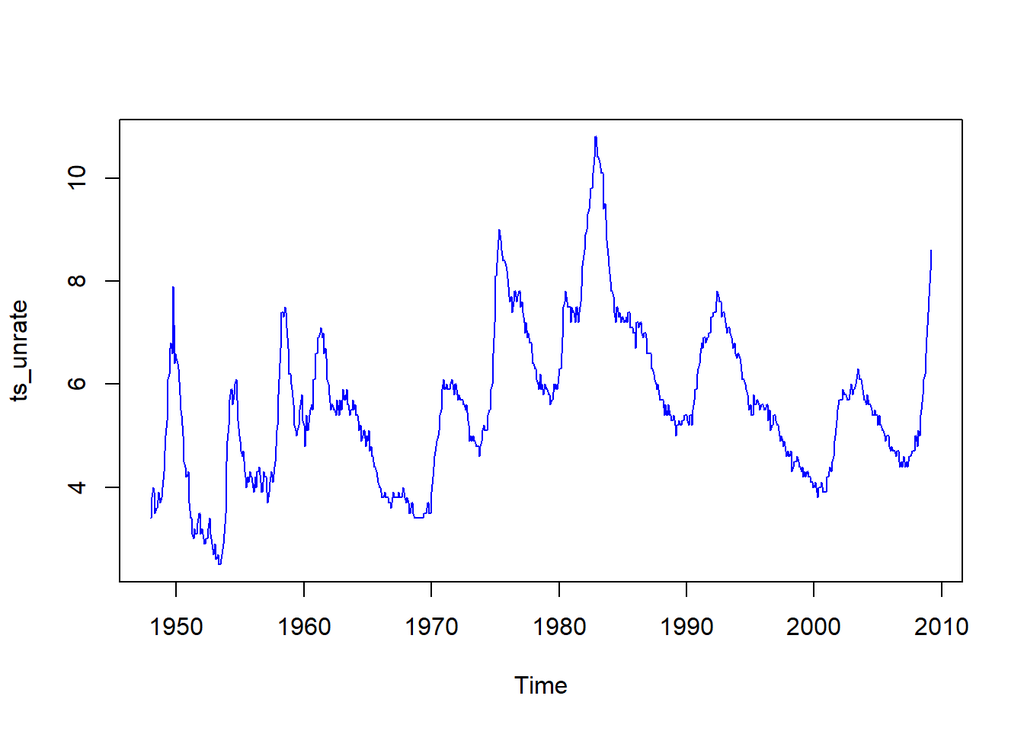

```r
ts_unrate = ts(unrate$Rate, frequency=12, start=c(1948,1))
plot(ts_unrate,type="l",col="blue")
```

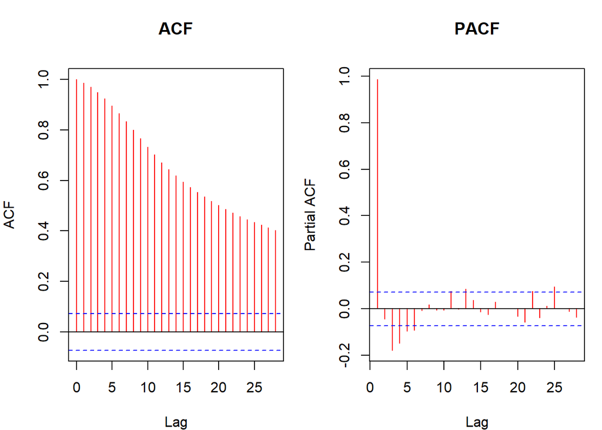

```r
par(mfrow=c(1,2),mar=c(4,4,4,1)) # 邊:下左上右
acf(unrate$Rate, type = "correlation", col="Red", main="ACF")
acf(unrate$Rate, type = "partial", col="Red", main="PACF")
```

```r
pl = c(1,-new_m11$coef[1:11])             # 特徵方程式，mean為[12]
roots = polyroot(pl)                      # 找解
cbind(roots=roots, Mod_roots=Mod(roots))  # 每個根的長度
```

```
##                       roots   Mod_roots
##  [1,]  0.7213096+1.0870135i 1.304563+0i
##  [2,] -1.1427487+0.3989529i 1.210388+0i
##  [3,] -0.7723762-0.9739137i 1.243010+0i
##  [4,]  1.1354496+0.2017578i 1.153235+0i
##  [5,]  0.0144528+1.2121540i 1.212240+0i
##  [6,] -0.7723762+0.9739137i 1.243010+0i
##  [7,]  0.0144528-1.2121540i 1.212240+0i
##  [8,]  1.0357787+0.0000000i 1.035779+0i
##  [9,]  1.1354496-0.2017578i 1.153235+0i
## [10,] -1.1427487-0.3989529i 1.210388+0i
## [11,]  0.7213096-1.0870135i 1.304563+0i
```

### AR(11) business cycles

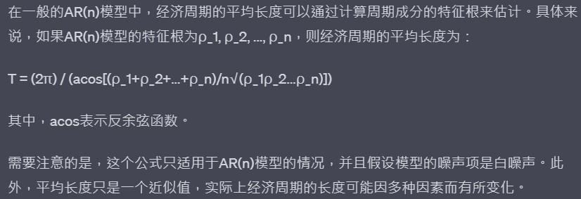

```r
knitr::include_graphics("C:/Users/user/Desktop/time_series/AR(11)_business_cycle.jpg")
```

```r
k = 2*pi/acos(Re(roots[1]/Mod(roots)[1]))
k # AR(2) : 6.379253
```

```
## [1] 6.379253
```

```r
k = 2*pi/acos((sum(roots)/prod(roots)^(1/11)))
k # AR(11) : 9.438663
```

```
## [1] 9.438663-0i
```

- Yes,因為特徵方程式的根含有虛數
- And the Business cycles of the fitted model is about 9.5 months.

## 4.

Consider the weekly yields(產量) of Moody’s Aaa and Baa seasoned bonds  
from January 5, 1962, to April 10, 2009. The data are obtained from  
the Federal Reserve Bank of St Louis. Weekly yields are averages of  
daily yields. Obtain the summary statistics (sample mean, standard  
deviation, skewness, excess kurtosis, minimum, and maximum) of the  
two yield series. Are the bond yields skewed? Do they have heavy tails?  
Answer the questions using 5% significance level

### weekly yields(產量) of Moody’s Aaa and Baa seasoned bonds

```r
Aaa = read.table("C:/Users/user/Desktop/time_series/HW/w-Aaa.txt",header = F)
head(Aaa)
```

```
##     V1 V2 V3   V4
## 1 1962  1  5 4.43
## 2 1962  1 12 4.42
## 3 1962  1 19 4.42
## 4 1962  1 26 4.41
## 5 1962  2  2 4.42
## 6 1962  2  9 4.42
```

```r
Baa = read.table("C:/Users/user/Desktop/time_series/HW/w-Baa.txt",header = F)
head(Baa)
```

```
##     V1 V2 V3   V4
## 1 1962  1  5 5.11
## 2 1962  1 12 5.09
## 3 1962  1 19 5.08
## 4 1962  1 26 5.08
## 5 1962  2  2 5.07
## 6 1962  2  9 5.08
```

### the summary statistics

- sample mean
- standard deviation
- skewness
- excess kurtosis
- minimum
- maximum

```r
basicStats(Aaa$V4)             # Aaa
```

```
##                X..Aaa.V4
## nobs         2467.000000
## NAs             0.000000
## Minimum         4.190000
## Maximum        15.850000
## 1. Quartile     5.985000
## 3. Quartile     8.930000
## Mean            7.830109
## Median          7.540000
## Sum         19316.880000
## SE Mean         0.048697
## LCL Mean        7.734618
## UCL Mean        7.925601
## Variance        5.850323
## Stdev           2.418744
## Skewness        0.857092
## Kurtosis        0.578605
```

```r
mean(Aaa$V4,na.rm=T)           # sample mean
```

```
## [1] 7.830109
```

```r
sqrt(var(Aaa$V4,na.rm=T))      # standard deviation
```

```
## [1] 2.418744
```

```r
skewness(Aaa$V4,na.rm=T)       # skewness
```

```
## [1] 0.857092
## attr(,"method")
## [1] "moment"
```

```r
kurtosis(Aaa$V4,na.rm=T)       # excess kurtosis
```

```
## [1] 0.5786054
## attr(,"method")
## [1] "excess"
```

```r
min(Aaa$V4,na.rm=T)            # minimum
```

```
## [1] 4.19
```

```r
max(Aaa$V4,na.rm=T)            # maximum
```

```
## [1] 15.85
```

```r
basicStats(Baa$V4)             # Baa
```

```
##                X..Baa.V4
## nobs         2467.000000
## NAs             0.000000
## Minimum         4.780000
## Maximum        17.290000
## 1. Quartile     6.990000
## 3. Quartile    10.200000
## Mean            8.847122
## Median          8.350000
## Sum         21825.850000
## SE Mean         0.054704
## LCL Mean        8.739852
## UCL Mean        8.954392
## Variance        7.382486
## Stdev           2.717073
## Skewness        0.929779
## Kurtosis        0.760896
```

```r
mean(Baa$V4,na.rm=T)           # sample mean
```

```
## [1] 8.847122
```

```r
sqrt(var(Baa$V4,na.rm=T))      # standard deviation
```

```
## [1] 2.717073
```

```r
skewness(Baa$V4,na.rm=T)       # skewness
```

```
## [1] 0.9297785
## attr(,"method")
## [1] "moment"
```

```r
kurtosis(Baa$V4,na.rm=T)       # excess kurtosis
```

```
## [1] 0.760896
## attr(,"method")
## [1] "excess"
```

```r
min(Baa$V4,na.rm=T)            # minimum
```

```
## [1] 4.78
```

```r
max(Baa$V4,na.rm=T)            # maximum
```

```
## [1] 17.29
```

### skewness is zero test

```r
skaaa = skewness(Aaa$V4, na.rm=TRUE)  # Aaa:0.857092
# Compute test statistic
t = nrow(Aaa)                         # 2467 # sum(is.na(Aaa$V4)) : 0
tl = skaaa/sqrt(6/t)                  # 17.37946
# Compute p-value
pv = 2*(1 - pnorm(tl,lower.tail = TRUE))
pv                                    # 0
```

```
## [1] 0
## attr(,"method")
## [1] "moment"
```

```r
skbaa = skewness(Baa$V4, na.rm=TRUE)  # Baa:0.9297785
# Compute test statistic
t = nrow(Baa)                         # 2467 # sum(is.na(Baa$V4)) : 0
tl = skbaa/sqrt(6/t)                  # 18.85335
# Compute p-value
pv = 2*(1 - pnorm(tl,lower.tail = TRUE))
pv                                    # 0
```

```
## [1] 0
## attr(,"method")
## [1] "moment"
```

- p-value = 0 < 0.05， reject H0，skewness of the Aaa yield series is not zero
- p-value = 0 < 0.05， reject H0，skewness of the Baa yield series is not zero
- 都右偏(Aaa:0.857092/Baa:0.9297785)

### skewness.norm.test

```r
skewness.norm.test(Aaa$V4)  # Aaa:0.857092 # p-value < 2.2e-16，reject H0
```

```
##
##  Skewness test for normality
##
## data:  Aaa$V4
## T = 0.85761, p-value < 2.2e-16
```

```r
skewness.norm.test(Baa$V4)  # Baa:0.929779 # p-value < 2.2e-16，reject H0
```

```
##
##  Skewness test for normality
##
## data:  Baa$V4
## T = 0.93034, p-value < 2.2e-16
```

### kurtosis is zero test

```r
Aaa_ku = kurtosis(Aaa$V4, na.rm=TRUE)  # Aaa:0.5786054
# Compute test statistic
k = nrow(Aaa)                          # 2467 # sum(is.na(Aaa$V4)) : 0
kl = (Aaa_ku)/sqrt(24/k)               # 5.866262
# Compute p-value
pv = 2*(1-pnorm(kl,lower.tail = TRUE))
pv                                     # 4.457306e-09
```

```
## [1] 4.457306e-09
## attr(,"method")
## [1] "excess"
```

```r
Baa_ku = kurtosis(Baa$V4, na.rm=TRUE)  # Baa:0.760896
# Compute test statistic
k = nrow(Baa)                          # 2467 # sum(is.na(Baa$V4)) : 0
kl = (Baa_ku)/sqrt(24/k)               # 7.714438
# Compute p-value
pv = 2*(1-pnorm(kl,lower.tail = TRUE))
pv                                     # 1.221245e-14
```

```
## [1] 1.221245e-14
## attr(,"method")
## [1] "excess"
```

- p-value = 4.457306e-09 < 0.05， reject H0，kurtosis of the Aaa yield series is not 3
- p-value = 1.221245e-14 < 0.05， reject H0，kurtosis of the Baa yield series is not 3
- 都厚尾(Aaa:0.5786054/# Baa:0.760896)

### kurtosis.norm.test

```r
kurtosis.norm.test(Aaa$V4)  # Aaa:0.578605,p-value < 2.2e-16,reject H0
```

```
##
##  Kurtosis test for normality
##
## data:  Aaa$V4
## T = 3.5815, p-value < 2.2e-16
```

```r
kurtosis.norm.test(Baa$V4)  # Baa:0.760896,p-value < 2.2e-16,reject H0
```

```
##
##  Kurtosis test for normality
##
## data:  Baa$V4
## T = 3.7639, p-value < 2.2e-16
```